# Risk Factor Analysis

## Outcome Variable

**Outcome Variable:** whz

## Predictor Variables

**Intervention Variable:** single

**Adjustment Set:**

unadjusted

## Stratifying Variables

The analysis was stratified on these variable(s):

- agecat
- studyid
- country

## Data Summary

| agecat | studyid | country | single | n_cell | n |
| --- | --- | --- | --- | --- | --- |
| Birth | COHORTS | GUATEMALA | 0 | 654 | 691 |
| Birth | COHORTS | GUATEMALA | 1 | 37 | 691 |
| Birth | COHORTS | INDIA | 0 | 4456 | 4463 |
| Birth | COHORTS | INDIA | 1 | 7 | 4463 |
| Birth | COHORTS | PHILIPPINES | 0 | 2789 | 2860 |
| Birth | COHORTS | PHILIPPINES | 1 | 71 | 2860 |
| Birth | MAL-ED | BANGLADESH | 0 | 215 | 215 |
| Birth | MAL-ED | BANGLADESH | 1 | 0 | 215 |
| Birth | MAL-ED | BRAZIL | 0 | 54 | 62 |
| Birth | MAL-ED | BRAZIL | 1 | 8 | 62 |
| Birth | MAL-ED | INDIA | 0 | 45 | 45 |
| Birth | MAL-ED | INDIA | 1 | 0 | 45 |
| Birth | MAL-ED | NEPAL | 0 | 26 | 26 |
| Birth | MAL-ED | NEPAL | 1 | 0 | 26 |
| Birth | MAL-ED | PERU | 0 | 205 | 228 |
| Birth | MAL-ED | PERU | 1 | 23 | 228 |
| Birth | MAL-ED | SOUTH AFRICA | 0 | 63 | 120 |
| Birth | MAL-ED | SOUTH AFRICA | 1 | 57 | 120 |
| Birth | MAL-ED | TANZANIA, UNITED REPUBLIC OF | 0 | 112 | 115 |
| Birth | MAL-ED | TANZANIA, UNITED REPUBLIC OF | 1 | 3 | 115 |
| Birth | PROBIT | BELARUS | 0 | 13277 | 13817 |
| Birth | PROBIT | BELARUS | 1 | 540 | 13817 |
| Birth | ZVITAMBO | ZIMBABWE | 0 | 12065 | 12864 |
| Birth | ZVITAMBO | ZIMBABWE | 1 | 799 | 12864 |
| 6 months | COHORTS | GUATEMALA | 0 | 827 | 894 |
| 6 months | COHORTS | GUATEMALA | 1 | 67 | 894 |
| 6 months | COHORTS | INDIA | 0 | 4955 | 4964 |
| 6 months | COHORTS | INDIA | 1 | 9 | 4964 |
| 6 months | COHORTS | PHILIPPINES | 0 | 2606 | 2674 |
| 6 months | COHORTS | PHILIPPINES | 1 | 68 | 2674 |
| 6 months | Guatemala BSC | GUATEMALA | 0 | 248 | 277 |
| 6 months | Guatemala BSC | GUATEMALA | 1 | 29 | 277 |
| 6 months | MAL-ED | BANGLADESH | 0 | 241 | 241 |
| 6 months | MAL-ED | BANGLADESH | 1 | 0 | 241 |
| 6 months | MAL-ED | BRAZIL | 0 | 179 | 209 |
| 6 months | MAL-ED | BRAZIL | 1 | 30 | 209 |
| 6 months | MAL-ED | INDIA | 0 | 234 | 234 |
| 6 months | MAL-ED | INDIA | 1 | 0 | 234 |
| 6 months | MAL-ED | NEPAL | 0 | 236 | 236 |
| 6 months | MAL-ED | NEPAL | 1 | 0 | 236 |
| 6 months | MAL-ED | PERU | 0 | 240 | 273 |
| 6 months | MAL-ED | PERU | 1 | 33 | 273 |
| 6 months | MAL-ED | SOUTH AFRICA | 0 | 140 | 254 |
| 6 months | MAL-ED | SOUTH AFRICA | 1 | 114 | 254 |
| 6 months | MAL-ED | TANZANIA, UNITED REPUBLIC OF | 0 | 239 | 247 |
| 6 months | MAL-ED | TANZANIA, UNITED REPUBLIC OF | 1 | 8 | 247 |
| 6 months | PROBIT | BELARUS | 0 | 15114 | 15757 |
| 6 months | PROBIT | BELARUS | 1 | 643 | 15757 |
| 6 months | TanzaniaChild2 | TANZANIA, UNITED REPUBLIC OF | 0 | 1834 | 2012 |
| 6 months | TanzaniaChild2 | TANZANIA, UNITED REPUBLIC OF | 1 | 178 | 2012 |
| 6 months | ZVITAMBO | ZIMBABWE | 0 | 7971 | 8474 |
| 6 months | ZVITAMBO | ZIMBABWE | 1 | 503 | 8474 |
| 24 months | COHORTS | GUATEMALA | 0 | 932 | 1021 |
| 24 months | COHORTS | GUATEMALA | 1 | 89 | 1021 |
| 24 months | COHORTS | INDIA | 0 | 3717 | 3726 |
| 24 months | COHORTS | INDIA | 1 | 9 | 3726 |
| 24 months | COHORTS | PHILIPPINES | 0 | 2361 | 2420 |
| 24 months | COHORTS | PHILIPPINES | 1 | 59 | 2420 |
| 24 months | MAL-ED | BANGLADESH | 0 | 212 | 212 |
| 24 months | MAL-ED | BANGLADESH | 1 | 0 | 212 |
| 24 months | MAL-ED | BRAZIL | 0 | 148 | 169 |
| 24 months | MAL-ED | BRAZIL | 1 | 21 | 169 |
| 24 months | MAL-ED | INDIA | 0 | 225 | 225 |
| 24 months | MAL-ED | INDIA | 1 | 0 | 225 |
| 24 months | MAL-ED | NEPAL | 0 | 228 | 228 |
| 24 months | MAL-ED | NEPAL | 1 | 0 | 228 |
| 24 months | MAL-ED | PERU | 0 | 176 | 201 |
| 24 months | MAL-ED | PERU | 1 | 25 | 201 |
| 24 months | MAL-ED | SOUTH AFRICA | 0 | 131 | 238 |
| 24 months | MAL-ED | SOUTH AFRICA | 1 | 107 | 238 |
| 24 months | MAL-ED | TANZANIA, UNITED REPUBLIC OF | 0 | 208 | 214 |
| 24 months | MAL-ED | TANZANIA, UNITED REPUBLIC OF | 1 | 6 | 214 |
| 24 months | PROBIT | BELARUS | 0 | 3828 | 3970 |
| 24 months | PROBIT | BELARUS | 1 | 142 | 3970 |
| 24 months | TanzaniaChild2 | TANZANIA, UNITED REPUBLIC OF | 0 | 6 | 6 |
| 24 months | TanzaniaChild2 | TANZANIA, UNITED REPUBLIC OF | 1 | 0 | 6 |
| 24 months | ZVITAMBO | ZIMBABWE | 0 | 388 | 432 |
| 24 months | ZVITAMBO | ZIMBABWE | 1 | 44 | 432 |

The following strata were considered:

- agecat: 24 months, studyid: COHORTS, country: GUATEMALA
- agecat: 24 months, studyid: COHORTS, country: INDIA
- agecat: 24 months, studyid: COHORTS, country: PHILIPPINES
- agecat: 24 months, studyid: MAL-ED, country: BANGLADESH
- agecat: 24 months, studyid: MAL-ED, country: BRAZIL
- agecat: 24 months, studyid: MAL-ED, country: INDIA
- agecat: 24 months, studyid: MAL-ED, country: NEPAL
- agecat: 24 months, studyid: MAL-ED, country: PERU
- agecat: 24 months, studyid: MAL-ED, country: SOUTH AFRICA
- agecat: 24 months, studyid: MAL-ED, country: TANZANIA, UNITED REPUBLIC OF
- agecat: 24 months, studyid: PROBIT, country: BELARUS
- agecat: 24 months, studyid: TanzaniaChild2, country: TANZANIA, UNITED REPUBLIC OF
- agecat: 24 months, studyid: ZVITAMBO, country: ZIMBABWE
- agecat: 6 months, studyid: COHORTS, country: GUATEMALA
- agecat: 6 months, studyid: COHORTS, country: INDIA
- agecat: 6 months, studyid: COHORTS, country: PHILIPPINES
- agecat: 6 months, studyid: Guatemala BSC, country: GUATEMALA
- agecat: 6 months, studyid: MAL-ED, country: BANGLADESH
- agecat: 6 months, studyid: MAL-ED, country: BRAZIL
- agecat: 6 months, studyid: MAL-ED, country: INDIA
- agecat: 6 months, studyid: MAL-ED, country: NEPAL
- agecat: 6 months, studyid: MAL-ED, country: PERU
- agecat: 6 months, studyid: MAL-ED, country: SOUTH AFRICA
- agecat: 6 months, studyid: MAL-ED, country: TANZANIA, UNITED REPUBLIC OF
- agecat: 6 months, studyid: PROBIT, country: BELARUS
- agecat: 6 months, studyid: TanzaniaChild2, country: TANZANIA, UNITED REPUBLIC OF
- agecat: 6 months, studyid: ZVITAMBO, country: ZIMBABWE
- agecat: Birth, studyid: COHORTS, country: GUATEMALA
- agecat: Birth, studyid: COHORTS, country: INDIA
- agecat: Birth, studyid: COHORTS, country: PHILIPPINES
- agecat: Birth, studyid: MAL-ED, country: BANGLADESH
- agecat: Birth, studyid: MAL-ED, country: BRAZIL
- agecat: Birth, studyid: MAL-ED, country: INDIA
- agecat: Birth, studyid: MAL-ED, country: NEPAL
- agecat: Birth, studyid: MAL-ED, country: PERU
- agecat: Birth, studyid: MAL-ED, country: SOUTH AFRICA
- agecat: Birth, studyid: MAL-ED, country: TANZANIA, UNITED REPUBLIC OF
- agecat: Birth, studyid: PROBIT, country: BELARUS
- agecat: Birth, studyid: ZVITAMBO, country: ZIMBABWE

### Dropped Strata

Some strata were dropped due to rare outcomes:

- agecat: Birth, studyid: MAL-ED, country: BANGLADESH
- agecat: Birth, studyid: MAL-ED, country: INDIA
- agecat: Birth, studyid: MAL-ED, country: NEPAL
- agecat: Birth, studyid: MAL-ED, country: TANZANIA, UNITED REPUBLIC OF
- agecat: 6 months, studyid: MAL-ED, country: BANGLADESH
- agecat: 6 months, studyid: MAL-ED, country: INDIA
- agecat: 6 months, studyid: MAL-ED, country: NEPAL
- agecat: 24 months, studyid: MAL-ED, country: BANGLADESH
- agecat: 24 months, studyid: MAL-ED, country: INDIA
- agecat: 24 months, studyid: MAL-ED, country: NEPAL
- agecat: 24 months, studyid: TanzaniaChild2, country: TANZANIA, UNITED REPUBLIC OF

## Methods Detail

We’re interested in the causal parameters $E[Y_a]$ for all values of $a \in \mathcal{A}$. These parameters represent the mean outcome if, possibly contrary to fact, we intervened to set all units to have $A=a$. Under the randomization and positivity assumptions, these are identified by the statistical parameters $\psi_a=E_W[E_{Y|A,W}(Y|A=a,W)]$. In addition, we’re interested in the mean of $Y$, $E[Y]$ under no intervention (the observed mean). We will estimate these parameters by using SuperLearner to fit the relevant likelihood factors – $E_{Y|A,W}(Y|A=a,W)$ and $p(A=a|W)$, and then updating our likelihood fit using a joint TMLE.

For unadjusted analyses ($W=\{\}$), initial likelihoods were estimated using Lrnr_glm to estimate the simple $E(Y|A)$ and Lrnr_mean to estimate $p(A)$. For adjusted analyses, a small library containing Lrnr_glmnet, Lrnr_xgboost, and Lrnr_mean was used.

Having estimated these parameters, we will then use the delta method to estimate relative risks and attributable risks relative to a prespecified baseline level of $A$.

# Results Detail

## Results Plots

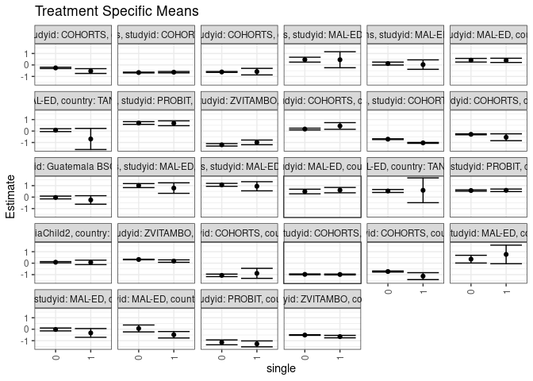

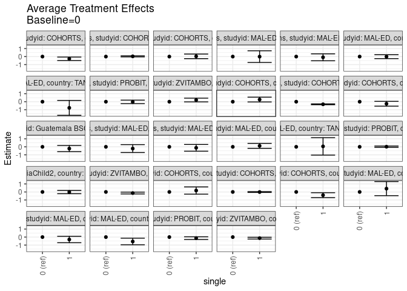

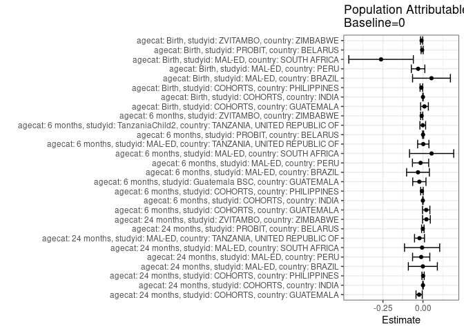

## Results Table

### Parameter: TSM

| agecat | studyid | country | intervention_level | baseline_level | estimate | ci_lower | ci_upper |
| --- | --- | --- | --- | --- | --- | --- | --- |
| Birth | COHORTS | GUATEMALA | 0 | NA | -1.0647095 | -1.1745225 | -0.9548964 |
| Birth | COHORTS | GUATEMALA | 1 | NA | -0.8875676 | -1.3234466 | -0.4516886 |
| Birth | COHORTS | INDIA | 0 | NA | -0.9764901 | -1.0121932 | -0.9407871 |
| Birth | COHORTS | INDIA | 1 | NA | -0.9871429 | -1.0249916 | -0.9492941 |
| Birth | COHORTS | PHILIPPINES | 0 | NA | -0.7277519 | -0.7749508 | -0.6805530 |
| Birth | COHORTS | PHILIPPINES | 1 | NA | -1.1321127 | -1.4342399 | -0.8299854 |
| Birth | MAL-ED | BRAZIL | 0 | NA | 0.3496296 | 0.0129664 | 0.6862928 |
| Birth | MAL-ED | BRAZIL | 1 | NA | 0.7625000 | -0.0474852 | 1.5724852 |
| Birth | MAL-ED | PERU | 0 | NA | -0.0216098 | -0.1479272 | 0.1047077 |
| Birth | MAL-ED | PERU | 1 | NA | -0.3230435 | -0.7049815 | 0.0588945 |
| Birth | MAL-ED | SOUTH AFRICA | 0 | NA | 0.0693651 | -0.2318566 | 0.3705868 |
| Birth | MAL-ED | SOUTH AFRICA | 1 | NA | -0.4821053 | -0.7631066 | -0.2011039 |
| Birth | PROBIT | BELARUS | 0 | NA | -1.1440163 | -1.3547984 | -0.9332343 |
| Birth | PROBIT | BELARUS | 1 | NA | -1.2760926 | -1.5328300 | -1.0193552 |
| Birth | ZVITAMBO | ZIMBABWE | 0 | NA | -0.5063746 | -0.5330721 | -0.4796771 |
| Birth | ZVITAMBO | ZIMBABWE | 1 | NA | -0.6430038 | -0.7493737 | -0.5366338 |
| 6 months | COHORTS | GUATEMALA | 0 | NA | 0.1718017 | 0.0948047 | 0.2487987 |
| 6 months | COHORTS | GUATEMALA | 1 | NA | 0.4414925 | 0.1503081 | 0.7326770 |
| 6 months | COHORTS | INDIA | 0 | NA | -0.7098951 | -0.7430287 | -0.6767615 |
| 6 months | COHORTS | INDIA | 1 | NA | -1.0322222 | -1.0700926 | -0.9943519 |
| 6 months | COHORTS | PHILIPPINES | 0 | NA | -0.2872026 | -0.3291300 | -0.2452752 |
| 6 months | COHORTS | PHILIPPINES | 1 | NA | -0.5425000 | -0.8411948 | -0.2438052 |
| 6 months | Guatemala BSC | GUATEMALA | 0 | NA | -0.0342809 | -0.1553992 | 0.0868373 |
| 6 months | Guatemala BSC | GUATEMALA | 1 | NA | -0.2501724 | -0.6199245 | 0.1195797 |
| 6 months | MAL-ED | BRAZIL | 0 | NA | 1.0031518 | 0.8277949 | 1.1785086 |
| 6 months | MAL-ED | BRAZIL | 1 | NA | 0.7866667 | 0.3287675 | 1.2445658 |
| 6 months | MAL-ED | PERU | 0 | NA | 1.0678194 | 0.9409494 | 1.1946895 |
| 6 months | MAL-ED | PERU | 1 | NA | 0.9442424 | 0.5458471 | 1.3426377 |
| 6 months | MAL-ED | SOUTH AFRICA | 0 | NA | 0.4880833 | 0.2887041 | 0.6874626 |
| 6 months | MAL-ED | SOUTH AFRICA | 1 | NA | 0.6086111 | 0.3747855 | 0.8424367 |
| 6 months | MAL-ED | TANZANIA, UNITED REPUBLIC OF | 0 | NA | 0.5343375 | 0.4035792 | 0.6650959 |
| 6 months | MAL-ED | TANZANIA, UNITED REPUBLIC OF | 1 | NA | 0.5925000 | -0.4882365 | 1.6732365 |
| 6 months | PROBIT | BELARUS | 0 | NA | 0.5734074 | 0.5140909 | 0.6327239 |
| 6 months | PROBIT | BELARUS | 1 | NA | 0.5906221 | 0.4800736 | 0.7011706 |
| 6 months | TanzaniaChild2 | TANZANIA, UNITED REPUBLIC OF | 0 | NA | 0.0809501 | 0.0261082 | 0.1357921 |
| 6 months | TanzaniaChild2 | TANZANIA, UNITED REPUBLIC OF | 1 | NA | 0.0674719 | -0.1266426 | 0.2615864 |
| 6 months | ZVITAMBO | ZIMBABWE | 0 | NA | 0.3190905 | 0.2926063 | 0.3455746 |
| 6 months | ZVITAMBO | ZIMBABWE | 1 | NA | 0.1810934 | 0.0741533 | 0.2880336 |
| 24 months | COHORTS | GUATEMALA | 0 | NA | -0.2556974 | -0.3128540 | -0.1985409 |
| 24 months | COHORTS | GUATEMALA | 1 | NA | -0.5310112 | -0.7397698 | -0.3222527 |
| 24 months | COHORTS | INDIA | 0 | NA | -0.6594835 | -0.6934635 | -0.6255034 |
| 24 months | COHORTS | INDIA | 1 | NA | -0.6300000 | -0.6887577 | -0.5712423 |
| 24 months | COHORTS | PHILIPPINES | 0 | NA | -0.6107920 | -0.6481622 | -0.5734219 |
| 24 months | COHORTS | PHILIPPINES | 1 | NA | -0.5806780 | -0.8650626 | -0.2962933 |
| 24 months | MAL-ED | BRAZIL | 0 | NA | 0.4633221 | 0.2501186 | 0.6765256 |
| 24 months | MAL-ED | BRAZIL | 1 | NA | 0.4576984 | -0.2403156 | 1.1557124 |
| 24 months | MAL-ED | PERU | 0 | NA | 0.1223153 | -0.0053144 | 0.2499451 |
| 24 months | MAL-ED | PERU | 1 | NA | 0.0329333 | -0.3795724 | 0.4454391 |
| 24 months | MAL-ED | SOUTH AFRICA | 0 | NA | 0.4143893 | 0.2545791 | 0.5741995 |
| 24 months | MAL-ED | SOUTH AFRICA | 1 | NA | 0.4024688 | 0.2173862 | 0.5875515 |
| 24 months | MAL-ED | TANZANIA, UNITED REPUBLIC OF | 0 | NA | 0.0763782 | -0.0483716 | 0.2011280 |
| 24 months | MAL-ED | TANZANIA, UNITED REPUBLIC OF | 1 | NA | -0.6933333 | -1.6135001 | 0.2268334 |
| 24 months | PROBIT | BELARUS | 0 | NA | 0.6988932 | 0.5829295 | 0.8148570 |
| 24 months | PROBIT | BELARUS | 1 | NA | 0.6778521 | 0.4657453 | 0.8899589 |
| 24 months | ZVITAMBO | ZIMBABWE | 0 | NA | -1.2012629 | -1.3088263 | -1.0936995 |
| 24 months | ZVITAMBO | ZIMBABWE | 1 | NA | -0.9897727 | -1.1935533 | -0.7859921 |

### Parameter: E(Y)

| agecat | studyid | country | intervention_level | baseline_level | estimate | ci_lower | ci_upper |
| --- | --- | --- | --- | --- | --- | --- | --- |
| Birth | COHORTS | GUATEMALA | NA | NA | -1.0552243 | -1.1617873 | -0.9486614 |
| Birth | COHORTS | INDIA | NA | NA | -0.9765068 | -1.0113301 | -0.9416835 |
| Birth | COHORTS | PHILIPPINES | NA | NA | -0.7377902 | -0.7844819 | -0.6910986 |
| Birth | MAL-ED | BRAZIL | NA | NA | 0.4029032 | 0.0896793 | 0.7161272 |
| Birth | MAL-ED | PERU | NA | NA | -0.0520175 | -0.1725298 | 0.0684947 |
| Birth | MAL-ED | SOUTH AFRICA | NA | NA | -0.1925833 | -0.4053570 | 0.0201904 |
| Birth | PROBIT | BELARUS | NA | NA | -1.1491782 | -1.3593933 | -0.9389630 |
| Birth | ZVITAMBO | ZIMBABWE | NA | NA | -0.5148609 | -0.5407634 | -0.4889583 |
| 6 months | COHORTS | GUATEMALA | NA | NA | 0.1920134 | 0.1173734 | 0.2666534 |
| 6 months | COHORTS | INDIA | NA | NA | -0.7104795 | -0.7428008 | -0.6781581 |
| 6 months | COHORTS | PHILIPPINES | NA | NA | -0.2936948 | -0.3352840 | -0.2521057 |
| 6 months | Guatemala BSC | GUATEMALA | NA | NA | -0.0568833 | -0.1722874 | 0.0585208 |
| 6 months | MAL-ED | BRAZIL | NA | NA | 0.9720774 | 0.8078144 | 1.1363403 |
| 6 months | MAL-ED | PERU | NA | NA | 1.0528816 | 0.9313005 | 1.1744626 |
| 6 months | MAL-ED | SOUTH AFRICA | NA | NA | 0.5421785 | 0.3900443 | 0.6943126 |
| 6 months | MAL-ED | TANZANIA, UNITED REPUBLIC OF | NA | NA | 0.5362213 | 0.4049390 | 0.6675036 |
| 6 months | PROBIT | BELARUS | NA | NA | 0.5741099 | 0.5141290 | 0.6340908 |
| 6 months | TanzaniaChild2 | TANZANIA, UNITED REPUBLIC OF | NA | NA | 0.0797577 | 0.0268998 | 0.1326156 |
| 6 months | ZVITAMBO | ZIMBABWE | NA | NA | 0.3108992 | 0.2851818 | 0.3366167 |
| 24 months | COHORTS | GUATEMALA | NA | NA | -0.2796964 | -0.3351582 | -0.2242346 |
| 24 months | COHORTS | INDIA | NA | NA | -0.6594122 | -0.6925753 | -0.6262491 |
| 24 months | COHORTS | PHILIPPINES | NA | NA | -0.6100579 | -0.6471813 | -0.5729344 |
| 24 months | MAL-ED | BRAZIL | NA | NA | 0.4626233 | 0.2567495 | 0.6684971 |
| 24 months | MAL-ED | PERU | NA | NA | 0.1111982 | -0.0118399 | 0.2342362 |
| 24 months | MAL-ED | SOUTH AFRICA | NA | NA | 0.4090301 | 0.2879441 | 0.5301161 |
| 24 months | MAL-ED | TANZANIA, UNITED REPUBLIC OF | NA | NA | 0.0547975 | -0.0703378 | 0.1799328 |
| 24 months | PROBIT | BELARUS | NA | NA | 0.6981406 | 0.5843775 | 0.8119038 |
| 24 months | ZVITAMBO | ZIMBABWE | NA | NA | -1.1797222 | -1.2787189 | -1.0807256 |

### Parameter: ATE

| agecat | studyid | country | intervention_level | baseline_level | estimate | ci_lower | ci_upper |
| --- | --- | --- | --- | --- | --- | --- | --- |
| Birth | COHORTS | GUATEMALA | 0 | 0 | 0.0000000 | 0.0000000 | 0.0000000 |
| Birth | COHORTS | GUATEMALA | 1 | 0 | 0.1771419 | -0.2723571 | 0.6266410 |
| Birth | COHORTS | INDIA | 0 | 0 | 0.0000000 | 0.0000000 | 0.0000000 |
| Birth | COHORTS | INDIA | 1 | 0 | -0.0106527 | -0.0626838 | 0.0413784 |
| Birth | COHORTS | PHILIPPINES | 0 | 0 | 0.0000000 | 0.0000000 | 0.0000000 |
| Birth | COHORTS | PHILIPPINES | 1 | 0 | -0.4043608 | -0.7101526 | -0.0985690 |
| Birth | MAL-ED | BRAZIL | 0 | 0 | 0.0000000 | 0.0000000 | 0.0000000 |
| Birth | MAL-ED | BRAZIL | 1 | 0 | 0.4128704 | -0.4642944 | 1.2900352 |
| Birth | MAL-ED | PERU | 0 | 0 | 0.0000000 | 0.0000000 | 0.0000000 |
| Birth | MAL-ED | PERU | 1 | 0 | -0.3014337 | -0.7037181 | 0.1008507 |
| Birth | MAL-ED | SOUTH AFRICA | 0 | 0 | 0.0000000 | 0.0000000 | 0.0000000 |
| Birth | MAL-ED | SOUTH AFRICA | 1 | 0 | -0.5514703 | -0.9634124 | -0.1395283 |
| Birth | PROBIT | BELARUS | 0 | 0 | 0.0000000 | 0.0000000 | 0.0000000 |
| Birth | PROBIT | BELARUS | 1 | 0 | -0.1320762 | -0.2999677 | 0.0358152 |
| Birth | ZVITAMBO | ZIMBABWE | 0 | 0 | 0.0000000 | 0.0000000 | 0.0000000 |
| Birth | ZVITAMBO | ZIMBABWE | 1 | 0 | -0.1366291 | -0.2462983 | -0.0269600 |
| 6 months | COHORTS | GUATEMALA | 0 | 0 | 0.0000000 | 0.0000000 | 0.0000000 |
| 6 months | COHORTS | GUATEMALA | 1 | 0 | 0.2696908 | -0.0315017 | 0.5708834 |
| 6 months | COHORTS | INDIA | 0 | 0 | 0.0000000 | 0.0000000 | 0.0000000 |
| 6 months | COHORTS | INDIA | 1 | 0 | -0.3223272 | -0.3726461 | -0.2720082 |
| 6 months | COHORTS | PHILIPPINES | 0 | 0 | 0.0000000 | 0.0000000 | 0.0000000 |
| 6 months | COHORTS | PHILIPPINES | 1 | 0 | -0.2552974 | -0.5569205 | 0.0463257 |
| 6 months | Guatemala BSC | GUATEMALA | 0 | 0 | 0.0000000 | 0.0000000 | 0.0000000 |
| 6 months | Guatemala BSC | GUATEMALA | 1 | 0 | -0.2158915 | -0.6049753 | 0.1731923 |
| 6 months | MAL-ED | BRAZIL | 0 | 0 | 0.0000000 | 0.0000000 | 0.0000000 |
| 6 months | MAL-ED | BRAZIL | 1 | 0 | -0.2164851 | -0.7068132 | 0.2738430 |
| 6 months | MAL-ED | PERU | 0 | 0 | 0.0000000 | 0.0000000 | 0.0000000 |
| 6 months | MAL-ED | PERU | 1 | 0 | -0.1235770 | -0.5416857 | 0.2945316 |
| 6 months | MAL-ED | SOUTH AFRICA | 0 | 0 | 0.0000000 | 0.0000000 | 0.0000000 |
| 6 months | MAL-ED | SOUTH AFRICA | 1 | 0 | 0.1205278 | -0.1867612 | 0.4278167 |
| 6 months | MAL-ED | TANZANIA, UNITED REPUBLIC OF | 0 | 0 | 0.0000000 | 0.0000000 | 0.0000000 |
| 6 months | MAL-ED | TANZANIA, UNITED REPUBLIC OF | 1 | 0 | 0.0581625 | -1.0304555 | 1.1467805 |
| 6 months | PROBIT | BELARUS | 0 | 0 | 0.0000000 | 0.0000000 | 0.0000000 |
| 6 months | PROBIT | BELARUS | 1 | 0 | 0.0172146 | -0.0669424 | 0.1013717 |
| 6 months | TanzaniaChild2 | TANZANIA, UNITED REPUBLIC OF | 0 | 0 | 0.0000000 | 0.0000000 | 0.0000000 |
| 6 months | TanzaniaChild2 | TANZANIA, UNITED REPUBLIC OF | 1 | 0 | -0.0134782 | -0.2151910 | 0.1882346 |
| 6 months | ZVITAMBO | ZIMBABWE | 0 | 0 | 0.0000000 | 0.0000000 | 0.0000000 |
| 6 months | ZVITAMBO | ZIMBABWE | 1 | 0 | -0.1379970 | -0.2481678 | -0.0278262 |
| 24 months | COHORTS | GUATEMALA | 0 | 0 | 0.0000000 | 0.0000000 | 0.0000000 |
| 24 months | COHORTS | GUATEMALA | 1 | 0 | -0.2753138 | -0.4917555 | -0.0588721 |
| 24 months | COHORTS | INDIA | 0 | 0 | 0.0000000 | 0.0000000 | 0.0000000 |
| 24 months | COHORTS | INDIA | 1 | 0 | 0.0294835 | -0.0383923 | 0.0973592 |
| 24 months | COHORTS | PHILIPPINES | 0 | 0 | 0.0000000 | 0.0000000 | 0.0000000 |
| 24 months | COHORTS | PHILIPPINES | 1 | 0 | 0.0301141 | -0.2567154 | 0.3169435 |
| 24 months | MAL-ED | BRAZIL | 0 | 0 | 0.0000000 | 0.0000000 | 0.0000000 |
| 24 months | MAL-ED | BRAZIL | 1 | 0 | -0.0056237 | -0.7354724 | 0.7242251 |
| 24 months | MAL-ED | PERU | 0 | 0 | 0.0000000 | 0.0000000 | 0.0000000 |
| 24 months | MAL-ED | PERU | 1 | 0 | -0.0893820 | -0.5211810 | 0.3424170 |
| 24 months | MAL-ED | SOUTH AFRICA | 0 | 0 | 0.0000000 | 0.0000000 | 0.0000000 |
| 24 months | MAL-ED | SOUTH AFRICA | 1 | 0 | -0.0119205 | -0.2564504 | 0.2326094 |
| 24 months | MAL-ED | TANZANIA, UNITED REPUBLIC OF | 0 | 0 | 0.0000000 | 0.0000000 | 0.0000000 |
| 24 months | MAL-ED | TANZANIA, UNITED REPUBLIC OF | 1 | 0 | -0.7697115 | -1.6982961 | 0.1588731 |
| 24 months | PROBIT | BELARUS | 0 | 0 | 0.0000000 | 0.0000000 | 0.0000000 |
| 24 months | PROBIT | BELARUS | 1 | 0 | -0.0210411 | -0.2391392 | 0.1970570 |
| 24 months | ZVITAMBO | ZIMBABWE | 0 | 0 | 0.0000000 | 0.0000000 | 0.0000000 |
| 24 months | ZVITAMBO | ZIMBABWE | 1 | 0 | 0.2114902 | -0.0189365 | 0.4419168 |

### Parameter: PAR

| agecat | studyid | country | intervention_level | baseline_level | estimate | ci_lower | ci_upper |
| --- | --- | --- | --- | --- | --- | --- | --- |
| Birth | COHORTS | GUATEMALA | 0 | NA | 0.0094852 | -0.0147667 | 0.0337371 |
| Birth | COHORTS | INDIA | 0 | NA | -0.0000167 | -0.0013175 | 0.0012841 |
| Birth | COHORTS | PHILIPPINES | 0 | NA | -0.0100383 | -0.0180234 | -0.0020533 |
| Birth | MAL-ED | BRAZIL | 0 | NA | 0.0532736 | -0.0651185 | 0.1716657 |
| Birth | MAL-ED | PERU | 0 | NA | -0.0304078 | -0.0726725 | 0.0118570 |
| Birth | MAL-ED | SOUTH AFRICA | 0 | NA | -0.2619484 | -0.4637798 | -0.0601170 |
| Birth | PROBIT | BELARUS | 0 | NA | -0.0051618 | -0.0115932 | 0.0012695 |
| Birth | ZVITAMBO | ZIMBABWE | 0 | NA | -0.0084862 | -0.0153217 | -0.0016507 |
| 6 months | COHORTS | GUATEMALA | 0 | NA | 0.0202117 | -0.0028363 | 0.0432598 |
| 6 months | COHORTS | INDIA | 0 | NA | -0.0005844 | -0.0018989 | 0.0007302 |
| 6 months | COHORTS | PHILIPPINES | 0 | NA | -0.0064922 | -0.0143124 | 0.0013279 |
| 6 months | Guatemala BSC | GUATEMALA | 0 | NA | -0.0226024 | -0.0640764 | 0.0188717 |
| 6 months | MAL-ED | BRAZIL | 0 | NA | -0.0310744 | -0.1022084 | 0.0400595 |
| 6 months | MAL-ED | PERU | 0 | NA | -0.0149379 | -0.0657047 | 0.0358290 |
| 6 months | MAL-ED | SOUTH AFRICA | 0 | NA | 0.0540951 | -0.0840196 | 0.1922099 |
| 6 months | MAL-ED | TANZANIA, UNITED REPUBLIC OF | 0 | NA | 0.0018838 | -0.0333985 | 0.0371662 |
| 6 months | PROBIT | BELARUS | 0 | NA | 0.0007025 | -0.0027536 | 0.0041586 |
| 6 months | TanzaniaChild2 | TANZANIA, UNITED REPUBLIC OF | 0 | NA | -0.0011924 | -0.0190386 | 0.0166537 |
| 6 months | ZVITAMBO | ZIMBABWE | 0 | NA | -0.0081912 | -0.0147675 | -0.0016150 |
| 24 months | COHORTS | GUATEMALA | 0 | NA | -0.0239990 | -0.0434587 | -0.0045392 |
| 24 months | COHORTS | INDIA | 0 | NA | 0.0000712 | -0.0016263 | 0.0017687 |
| 24 months | COHORTS | PHILIPPINES | 0 | NA | 0.0007342 | -0.0064389 | 0.0079073 |
| 24 months | MAL-ED | BRAZIL | 0 | NA | -0.0006988 | -0.0913905 | 0.0899929 |
| 24 months | MAL-ED | PERU | 0 | NA | -0.0111172 | -0.0649789 | 0.0427445 |
| 24 months | MAL-ED | SOUTH AFRICA | 0 | NA | -0.0053592 | -0.1152975 | 0.1045791 |
| 24 months | MAL-ED | TANZANIA, UNITED REPUBLIC OF | 0 | NA | -0.0215807 | -0.0527095 | 0.0095481 |
| 24 months | PROBIT | BELARUS | 0 | NA | -0.0007526 | -0.0085798 | 0.0070746 |
| 24 months | ZVITAMBO | ZIMBABWE | 0 | NA | 0.0215407 | -0.0026932 | 0.0457745 |